# Single Peptide Results Analysis

Caleb Easterly

## Introduction

The single peptide analysis methods and results are contained in this document.

## Five peptide analysis

The five peptides are as follows:

```r
fivepep <- c('AFLPGSLVDTRPVR',
             'DIAMQIAAVNPTYLNREEVPTEVIEHEK',
             'DLFKNPIHPYTK',
             'DVTIEAVNSLYEK',
             'EVPDWAAQLNENTNVKGLRIAVPK')
```

## Unipept

### Process

- Paste the tabular list of peptides into the Unipept ‘Metaproteomics Analysis’ web application (https://morty.ugent.be/mpa)
- Parameters:
  - Equate I and L: FALSE
  - Filter duplicate peptides: FALSE
  - Advanced missed cleavage handling: TRUE
- Download results
- Annotate each peptide with only the GO terms that are present in 5% or more of the proteins (percentages are returned in GO term column)

```r
library(dplyr)
library(stringr)
cov_pat <- "\ \\(.{3,4}\\)"
uni <- read.csv('unipept_20_peptides_result.csv',
                stringsAsFactors = FALSE) %>%
    select(peptide,
           uni_go_bp = GO..biological.process.,
           uni_go_mf = GO..molecular.function.,
           uni_go_cc = GO..cellular.component.) %>%
    filter(peptide %in% fivepep) %>%
    mutate(uni_go_bp = str_replace_all(string = uni_go_bp, pattern = cov_pat, replacement = ""),
           uni_go_mf = str_replace_all(string = uni_go_mf, pattern = cov_pat, replacement = ""),
           uni_go_cc = str_replace_all(string = uni_go_cc, pattern = cov_pat, replacement = ""))
```

## eggNOG mapper

- Use the Galaxy version of eggNOG mapper, on Galaxy-P
- Parameters:
  - Annotation type: DIAMOND
  - Scoring matrix and gap costs: PAM30, 9 and 1
  - Taxonomic Scope: Bacteria
  - Orthologs: use all orthologs
  - Gene Ontology evidence: use non-electronic terms
  - Seed Orthology Search Options
    - Min e-value: 200000
    - Min bit score: 20
- Download and compare GO terms

```r
em <- read.delim("eggnog_mapper_20_sequences_results.tabular",
                 stringsAsFactors = FALSE,
                 header=FALSE) %>%
    select(peptide = V1, em_prot = V2, em_go = V6, em_gene = V5, em_descript = V13) %>%
    filter(peptide %in% fivepep) %>%
    mutate(em_go = str_replace_all(em_go, pattern = ",", replacement = "; "))
```

## BLASTP against UniProt

- Use the UniProtKB BLAST web search on each peptide, one-by-one
- Parameters
  - Target database: UniProtKB
  - E-Threshold: 10
  - Matrix: Auto
  - Filtering: None
  - Gapped: Yes
  - Hits: 50
- For each peptide, download the result list and get all GO terms and TaxID associated with that peptide
- To match Unipept, annotate each peptide with only the GO terms that are present in 5% or more of the proteins
- Get the most frequent protein name
- For taxonomy, we can also calculate the lowest common ancestor of each peptide (TODO)

```r
peptide <- rep(0, 5)
blast_go <- rep(0, 5)
files <- list.files('uniprot_blastp_outputs')
for (i in 1:5){
    peptide[i] <- fivepep[i]
    result <- read.delim(paste('uniprot_blastp_outputs', paste(fivepep[i], '.tab', sep=""), sep="/"),
                   stringsAsFactors = FALSE,
                   na.strings = c("", "NA", "NaN"))
    gos <- table(unlist(str_split(result$Gene.ontology.IDs, "; ")))/50
    blast_go[i] <- paste(names(gos)[which(gos > 0.05)], collapse = "; ")
}
blast <- data.frame(peptide, blast_go, stringsAsFactors = FALSE)
```

## MetaGOmics

- Upload HOMD to metaGOmics
- Parameters:
  - Uniprot database: Uniprot sprot
  - Blast e-value cutoff: 1e-10
  - Use only top hit?: TRUE
- Result URL: https://www.yeastrc.org/metagomics/viewUploadedFasta.do?uid=42jgJAcLHHZBoRQk
- One-by-one, upload peptides and run
- Download results individually, combine into table

```r
peptide <- rep(0, 5)
mg_go <- rep(0, 5)
dir <- 'metaGOmics_single_peptides_outputs/'
files <- list.files(dir)
for (i in 1:5){
    peptide[i] <- fivepep[i]
    result <- read.delim(paste(dir, paste(fivepep[i], '.txt', sep=""), sep=""),
                   stringsAsFactors = FALSE,
                   na.strings = c("", "NA", "NaN"),
                   comment.char = "#")
    gos <- result$GO.acc
    mg_go[i] <- paste(gos, collapse = "; ")
}
mg <- data.frame(peptide, mg_go, stringsAsFactors = FALSE)
```

## Combine all of the results:

```r
all_results <- plyr::join_all(list(em, blast, mg, uni), by = "peptide")
```

All of the results are below:

```r
library(pander)
# knitr::kable(all_results)
pander::pander(all_results, split.cell = 80, split.table = Inf)
```

| peptide | em_prot | em_go | em_gene | em_descript | blast_go | mg_go | uni_go_bp | uni_go_mf | uni_go_cc |
| --- | --- | --- | --- | --- | --- | --- | --- | --- | --- |
| AFLPGSLVDTRPVR | 637911.AM305_10041 | GO:0003674; GO:0003676; GO:0003723; GO:0003729; GO:0003735; GO:0005198; GO:0005488; GO:0005575; GO:0005622; GO:0005623; GO:0005737; GO:0005829; GO:0005840; GO:0006412; GO:0006417; GO:0008150; GO:00081… | RPSA | thus facilitating recognition of the initiation point. It is needed to translate mRNA with a short Shine-Dalgarno (SD) purine-rich sequence (By similarity) | GO:0003723; GO:0003735; GO:0005840; GO:0006412 | GO:0005840; GO:0005198; GO:1901363; GO:0006412; GO:0006417; GO:0017148; GO:0008150; GO:0010556; GO:0015935; GO:0010558; GO:0034248; GO:0034249; GO:0005575; GO:0032991; GO:0008152; GO:0044391; GO:00000… | GO:0006412 | GO:0003723;GO:0003735 | GO:0005840 |
| DIAMQIAAVNPTYLNREEVPTEVIEHEK | 479436.Vpar_0857 | GO:0003674; GO:0003676; GO:0003723; GO:0003746; GO:0005488; GO:0005575; GO:0005618; GO:0005622; GO:0005623; GO:0005737; GO:0005829; GO:0005886; GO:0006412; GO:0006414; GO:0008135; GO:0008150; GO:00081… | TSF | Associates with the EF-Tu.GDP complex and induces the exchange of GDP to GTP. It remains bound to the aminoacyl-tRNA.EF- Tu.GTP complex up to the GTP hydrolysis stage on the ribosome (By similarity) | GO:0003746; GO:0005737 | GO:0008152; GO:0043170; GO:0044464; GO:0003723; GO:0044267; GO:0043603; GO:0043604; GO:0006807; GO:0044271; GO:0003674; GO:0008135; GO:0005737; GO:0003676; GO:1901363; GO:0019538; GO:0003746; GO:00430… |  | GO:0003746 | GO:0005737 |
| DLFKNPIHPYTK | 457405.FSDG_00110 |  |  | ATP-binding protein | GO:0005524; GO:0015833; GO:0016887 | GO:0016817; GO:0016818; GO:0044464; GO:0048869; GO:0051716; GO:0043934; GO:0009605; GO:1901363; GO:0006810; GO:0008104; GO:0048646; GO:0032549; GO:0032550; GO:0008150; GO:0032553; GO:0050896; GO:00325… | GO:0015833 | GO:0005524;GO:0016887 |  |
| DVTIEAVNSLYEK | 479436.Vpar_0475 |  | MOAB | molybdenum cofactor | GO:0001732; GO:0003743; GO:0005829; GO:0006777; GO:0016282; GO:0032436; GO:0033290; GO:0034613; GO:0070196; GO:0071540; GO:1900182 | GO:0008152; GO:0043170; unknownfun; GO:0018130; unknowncmp; GO:0006732; GO:0051189; GO:1901360; GO:0006807; GO:0003674; GO:1901362; GO:0019538; GO:0043545; GO:1901564; GO:0090407; GO:1901566; GO:00464… | GO:0006777 |  |  |
| EVPDWAAQLNENTNVKGLRIAVPK | 349123.Lreu23DRAFT_4361 | GO:0008150; GO:0040007 | GATA | Allows the formation of correctly charged Gln-tRNA(Gln) through the transamidation of misacylated Glu-tRNA(Gln) in organisms which lack glutaminyl-tRNA synthetase. The reaction takes place in the pres… | GO:0004040; GO:0005524; GO:0006412; GO:0016740; GO:0030956; GO:0050567 | GO:0044464; GO:0006807; GO:1901363; GO:0006412; GO:0032549; GO:0032550; GO:0008150; GO:0032553; GO:0032555; GO:0034641; GO:0032559; GO:0034645; GO:0044237; GO:0044238; GO:1901265; GO:0036094; GO:00309… | GO:0006412 | GO:0004040;GO:0005524;GO:0050567 | GO:0030956 |

## Let’s go through the peptides one-by-one

### AFLPGSLVDTRPVR

Here, BLAST and Unipept give the same GO terms:

```r
n <- 1
blast <- str_split(all_results[n, 'blast_go'], "; ", simplify=TRUE)
uni <- c(str_split(all_results[n, 'uni_go_bp'], ";", simplify=TRUE),
         str_split(all_results[n, 'uni_go_mf'], ";", simplify=TRUE),
         str_split(all_results[n, 'uni_go_cc'], ";", simplify=TRUE))
print(all_results[n, 'peptide'])
```

```
## [1] "AFLPGSLVDTRPVR"
```

```r
setequal(uni, blast)
```

```
## [1] TRUE
```

```r
#buni <- intersect(uni, blast)
buni <- blast
buni_split <- str_split(buni, "; ", simplify = TRUE)
buni
```

```
##      [,1]         [,2]         [,3]         [,4]
## [1,] "GO:0003723" "GO:0003735" "GO:0005840" "GO:0006412"
```

This is the metaGOmics list:

```r
metaGOmics_list <- c(str_split(all_results[n, 'mg_go'], "; ", simplify=TRUE))
```

And eggNOG

```r
eggnog_list <- c(str_split(all_results[n, 'em_go'], "; ", simplify =TRUE))
```

Let’s go to the QuickGO API to get the names of the BLAST/Unipept terms.

```r
library(httr)
library(jsonlite)
get_go_names <- function(id_vector){
    base_url <- 'https://www.ebi.ac.uk/QuickGO/services/ontology/go/terms/'
    terms <- str_replace(id_vector, ":", "%3A")
    joined_terms <- paste(terms, collapse="%2C")
    term_url <- paste(base_url, joined_terms, sep="")
    term_info <- GET(term_url, accept("application/json"))
    json <- toJSON(content(term_info))
    names <- unlist(fromJSON(json)$results$name)
    names
}
get_go_names(buni_split)
```

```
## [1] "translation"
## [2] "ribosome"
## [3] "RNA binding"
## [4] "structural constituent of ribosome"
```

On the other hand, both eggNOG mapper and metaGOmics give huge lists of GO terms. Are the 4 BLAST+Unipept terms contained in these lists?

Does eggnog mapper contain all BLAST/Unipept GO terms?

```r
em_buni <- intersect(eggnog_list, buni)
em_num_buni <- length(em_buni)
em_num_buni == length(buni_split)
```

```
## [1] TRUE
```

Does metagomics contain all BLAST/Unipept GO terms?

```r
mg_buni <- intersect(metaGOmics_list, buni)
mg_num_buni <- length(mg_buni)
mg_num_buni == length(buni_split)
```

```
## [1] TRUE
```

The question is, then, what the other terms are.

The other terms could be related to the 4 we found in several ways:

1. They could be more general terms (ancestors) of the 4 we found
2. They could be more specific terms (descendants) of the 4 we found
3. They could be terms that are not ancestors or descendants. These may be ‘extraneous’ GO terms.

However, we can also consider that terms that are not ancestors or descendants can be either closely or distantly related to the 4 we found. For this analysis, let’s define ‘closely related’ as ‘an ancestor, descendant, or child of ancestor’ of the 4 terms. Terms that are not closely related are declared to be extraneous. So, we have 5 categories:

1. original terms (BLAST terms)
2. ancestors
3. descendants
4. children of ancestors
5. extraneous

Let’s look at each of the latter 4 categories in turn (we already determined that 4 of each of the metaGOmics and eggNOG mapper terms are the 4 BLAST/Unipept terms).

### Ancestors

```r
# get all ancestors of the 4 terms
get_go_ancestors <- function(id_vector){
    base_url <- 'https://www.ebi.ac.uk/QuickGO/services/ontology/go/terms/'
    terms <- str_replace(id_vector, ":", "%3A")
    joined_terms <- paste(terms, collapse="%2C")
    term_url <- paste(base_url, joined_terms, '/ancestors?relations=is_a', sep="")
    term_info <- GET(term_url, accept("application/json"))
    json <- toJSON(content(term_info))
    names <- unlist(fromJSON(json)$results$ancestors)
    names
}
ancestors <- get_go_ancestors(buni_split)
head(get_go_names(ancestors))
```

```
## [1] "molecular_function"
## [2] "amide biosynthetic process"
## [3] "cellular amide metabolic process"
## [4] "nitrogen compound metabolic process"
## [5] "peptide metabolic process"
## [6] "translation"
```

Now, let’s look at the overlap between the ancestors and eggnog mapper, and between the ancestors and metaGOmics:

eggnog mapper

```r
em_ancestors <- intersect(eggnog_list, ancestors)
em_num_ancestors <- length(em_ancestors)
em_num_ancestors
```

```
## [1] 34
```

```r
em_ancestors
```

```
##  [1] "GO:0003674" "GO:0003676" "GO:0003723" "GO:0003735" "GO:0005198"
##  [6] "GO:0005488" "GO:0005575" "GO:0005840" "GO:0006412" "GO:0008150"
## [11] "GO:0008152" "GO:0009058" "GO:0009059" "GO:0009987" "GO:0019538"
## [16] "GO:0032991" "GO:0034645" "GO:0043170" "GO:0043226" "GO:0043228"
## [21] "GO:0043229" "GO:0043232" "GO:0044237" "GO:0044238" "GO:0044249"
## [26] "GO:0044260" "GO:0044267" "GO:0044424" "GO:0044444" "GO:0044464"
## [31] "GO:0071704" "GO:0097159" "GO:1901363" "GO:1901576"
```

metagomics

```r
mg_ancestors <- intersect(metaGOmics_list, ancestors)
mg_num_ancestors <- length(mg_ancestors)
mg_num_ancestors
```

```
## [1] 44
```

```r
mg_ancestors
```

```
##  [1] "GO:0005840" "GO:0005198" "GO:1901363" "GO:0006412" "GO:0008150"
##  [6] "GO:0005575" "GO:0032991" "GO:0008152" "GO:0043603" "GO:0043604"
## [11] "GO:0003674" "GO:0003676" "GO:0043043" "GO:0044424" "GO:0044444"
## [16] "GO:0009058" "GO:0009059" "GO:0006518" "GO:0044464" "GO:0003723"
## [21] "GO:0006807" "GO:0003735" "GO:0034641" "GO:0034645" "GO:0044237"
## [26] "GO:0044238" "GO:0044249" "GO:0005488" "GO:0044260" "GO:0043170"
## [31] "GO:0044267" "GO:0044271" "GO:0019538" "GO:1901564" "GO:1901566"
## [36] "GO:1901576" "GO:1990904" "GO:0009987" "GO:0043226" "GO:0097159"
## [41] "GO:0043228" "GO:0043229" "GO:0043232" "GO:0071704"
```

```r
intersect(eggnog_list, metaGOmics_list)
```

```
##  [1] "GO:0003674" "GO:0003676" "GO:0003723" "GO:0003729" "GO:0003735"
##  [6] "GO:0005198" "GO:0005488" "GO:0005575" "GO:0005737" "GO:0005840"
## [11] "GO:0006412" "GO:0006417" "GO:0008150" "GO:0008152" "GO:0009058"
## [16] "GO:0009059" "GO:0009889" "GO:0009890" "GO:0009892" "GO:0009987"
## [21] "GO:0010468" "GO:0010556" "GO:0010558" "GO:0010605" "GO:0010608"
## [26] "GO:0015935" "GO:0016020" "GO:0017148" "GO:0019222" "GO:0019538"
## [31] "GO:0022627" "GO:0030529" "GO:0031323" "GO:0031324" "GO:0031326"
## [36] "GO:0031327" "GO:0032268" "GO:0032269" "GO:0032991" "GO:0034645"
## [41] "GO:0043170" "GO:0043226" "GO:0043228" "GO:0043229" "GO:0043232"
## [46] "GO:0044237" "GO:0044238" "GO:0044249" "GO:0044260" "GO:0044267"
## [51] "GO:0044391" "GO:0044422" "GO:0044424" "GO:0044444" "GO:0044445"
## [56] "GO:0044446" "GO:0044464" "GO:0048519" "GO:0048523" "GO:0050789"
## [61] "GO:0050794" "GO:0051246" "GO:0051248" "GO:0060255" "GO:0065007"
## [66] "GO:0071704" "GO:0080090" "GO:0097159" "GO:1901363" "GO:1901576"
## [71] "GO:2000112" "GO:2000113" "GO:2000765" "GO:2000766"
```

```r
length(intersect(eggnog_list, metaGOmics_list))
```

```
## [1] 74
```

### Descendants

```r
# get all childen of the 4 terms
get_go_descendants <- function(id_vector){
    base_url <- 'https://www.ebi.ac.uk/QuickGO/services/ontology/go/terms/'
    terms <- str_replace(id_vector, ":", "%3A")
    joined_terms <- paste(terms, collapse="%2C")
    term_url <- paste(base_url, joined_terms, '/descendants?relations=is_a', sep="")
    term_info <- GET(term_url, accept("application/json"))
    json <- toJSON(content(term_info))
    names <- unlist(fromJSON(json)$results$descendants)
    names
}
descendants <- get_go_descendants(buni_split)
head(get_go_names(descendants))
```

```
## [1] "G-quadruplex RNA binding"
## [2] "steroid receptor RNA activator RNA binding"
## [3] "cytoplasmic translation"
## [4] "pre-mRNA binding"
## [5] "mRNA 5'-UTR binding"
## [6] "tRNA binding"
```

eggNOG overlap with descendants:

```r
em_descendants <- intersect(descendants, eggnog_list)
em_num_descendants <- length(em_descendants)
em_num_descendants
```

```
## [1] 6
```

MetaGOmics overlap:

```r
mg_descendants <- intersect(descendants, metaGOmics_list)
mg_num_descendants <- length(mg_descendants)
mg_num_descendants
```

```
## [1] 5
```

### Children of ancestors

Function to get children

```r
get_children <- function(goids){
    base_url <- 'https://www.ebi.ac.uk/QuickGO/services/ontology/go/terms/'
    terms <- str_replace(goids, ":", "%3A")
    joined_terms <- paste(terms, collapse="%2C")
    term_url <- paste(base_url, joined_terms, sep="")
    term_info <- GET(term_url, accept("application/json"))
    json <- toJSON(content(term_info))
    children <- fromJSON(json)$results$children
    children_is_a <- lapply(children, function(x) unlist(x[x$relation == "is_a", ]$id))
    return(children_is_a)
}
```

Get children of ancestors (that are not ancestors):

```r
children_of_ancestors <- setdiff(unlist(get_children(ancestors)), ancestors)
```

Get overlap.

EggNOG mapper:

```r
em_ancestors_kids <- intersect(eggnog_list, children_of_ancestors)
em_num_ancestors_kids <- length(em_ancestors_kids)
em_num_ancestors_kids
```

```
## [1] 13
```

MetaGOmics

```r
mg_ancestors_kids <- intersect(metaGOmics_list, children_of_ancestors)
mg_num_ancestors_kids <- length(mg_ancestors_kids)
mg_num_ancestors_kids
```

```
## [1] 10
```

### Extraneous

So, the terms that are designated ‘extraneous’ are those that remain.

We define the set of closely related terms below, then look at each tool to see how many terms are closely related.

```r
closely_related <- union_all(buni_split, descendants, ancestors, children_of_ancestors)
```

#### Eggnog Mapper

```r
em_extraneous <- setdiff(eggnog_list, closely_related)
em_num_extraneous <- length(em_extraneous)
em_num_extraneous
```

```
## [1] 32
```

#### MetaGOmics

```r
mg_extraneous <- setdiff(metaGOmics_list, closely_related)
mg_num_extraneous <- length(mg_extraneous)
mg_num_extraneous
```

```
## [1] 45
```

```r
mg_extraneous
```

```
##  [1] "GO:0006417" "GO:0017148" "GO:0010556" "GO:0015935" "GO:0010558"
##  [6] "GO:0034248" "GO:0034249" "GO:0000028" "GO:0010605" "GO:0010608"
## [11] "GO:0050789" "GO:0050794" "GO:2000112" "GO:2000113" "GO:0065003"
## [16] "GO:0010629" "GO:0071826" "GO:0043933" "GO:0030529" "GO:0034622"
## [21] "GO:0032268" "GO:0032269" "GO:0060255" "GO:0022607" "GO:0009889"
## [26] "GO:0009890" "GO:0009892" "GO:0051171" "GO:0051172" "GO:0019222"
## [31] "GO:0080090" "GO:0022618" "GO:0048519" "GO:0048523" "GO:0010468"
## [36] "GO:0051246" "GO:0051248" "GO:0022627" "GO:0044822" "GO:2000765"
## [41] "GO:2000766" "GO:0031323" "GO:0031324" "GO:0031326" "GO:0031327"
```

## Results

Let’s look at the full distribution of terms in the five categories for each of eggnog mapper and metaGOmics.

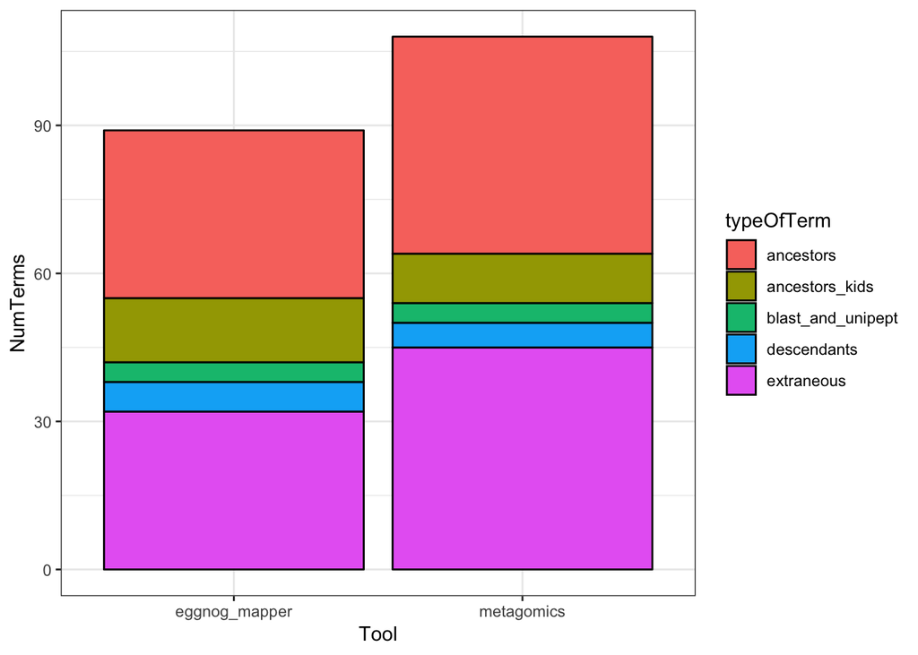

```r
term_df <- data.frame(
    typeOfTerm = rep(c("blast_and_unipept", "descendants", "ancestors", "ancestors_kids", "extraneous"), 2),
    NumTerms = c(em_num_buni, em_num_descendants, em_num_ancestors, em_num_ancestors_kids, em_num_extraneous,
             mg_num_buni, mg_num_descendants, mg_num_ancestors, mg_num_ancestors_kids, mg_num_extraneous),
    Tool = rep(c("eggnog_mapper", "metagomics"), each = 5)
)
library(ggplot2)
ggplot(term_df) +
    geom_bar(aes(x = Tool, y = NumTerms, fill = typeOfTerm), color = "black", stat = "identity") +
    theme_bw()
```

```r
colnames(all_results)
```

```
##  [1] "peptide"     "em_prot"     "em_go"       "em_gene"     "em_descript"
##  [6] "blast_go"    "mg_go"       "uni_go_bp"   "uni_go_mf"   "uni_go_cc"
```

```r
# TODO: Restructure to where you split within for loop
are_equal <- function(list1, list2){
  # Removes spaces and split into list along semicolons
  list1 <- str_split(
              gsub("\\s","",list1),
              ";", simplify=TRUE)
  list2 <- str_split(
              gsub("\\s","",list2),
              ";", simplify=TRUE)

  # Tests if list1 and list2 are equal in identity (disregards order)
  equalist <- character()
  for (i in 1:nrow(list1)){
    equalist[i] <- setequal(
      list1[i,list1[i,] != ""],
      list2[i,list2[i,] != ""])
  }
  equalist
}

calc_paths <- function(targ_list, ref_list){
  for (i in 1:length(targ_list)){
    extraneous <- str_split(
              gsub("\\s","",ref_list[i]),
              ";", simplify=TRUE)
    for (j in 1:length(targ_list)){
      print(j)
      print(targ_list[j])
    }
  }
}

n <- nrow(all_results)
output <- data.frame(Peptide = all_results[,'peptide'],
                     BLAST = character(n),
                     Unipept = character(n),
                     Equal = logical(n),
                     EggNOG.Ancestors = character(n),
                     stringsAsFactors = FALSE)
#for (n in 1:2){
for (n in 1:nrow(all_results)){
  blast <- str_split(all_results[n, 'blast_go'], "; ", simplify=TRUE)
  uni <- c(str_split(all_results[n, 'uni_go_bp'], ";", simplify=TRUE),
         str_split(all_results[n, 'uni_go_mf'], ";", simplify=TRUE),
         str_split(all_results[n, 'uni_go_cc'], ";", simplify=TRUE))
  blast <- blast[blast != ""]
  uni <- uni[uni != ""]
  #setequal(uni,blast)
  buni <- blast
  buni_split <- str_split(buni, ";", simplify = TRUE)
  metaGOmics_list <- c(str_split(all_results[n, 'mg_go'], "; ", simplify=TRUE))
  eggnog_list <- c(str_split(all_results[n, 'em_go'], "; ", simplify =TRUE))

  ancestors <- get_go_ancestors(buni_split)
  #descendants <- get_go_descendants(buni_split)
  #children_of_ancestors <- setdiff(unlist(get_children(ancestors)), ancestors)
  #closely_related <- union_all(buni_split, descendants, ancestors, children_of_ancestors)
  #head(get_go_names(ancestors))
  #head(get_go_names(descendants))

  em_ancestors <- intersect(eggnog_list, ancestors)
  #em_descendants <- intersect(descendants, eggnog_list)
  #mg_descendants <- intersect(descendants, metaGOmics_list)
  #em_extraneous <- setdiff(eggnog_list, closely_related)
  #mg_extraneous <- setdiff(metaGOmics_list, closely_related)
  #em_ancestors_kids <- intersect(eggnog_list, children_of_ancestors)

  #row <- c(all_results[n, 'blast_go'],
  #         paste(uni, collapse=";"),
  #         setequal(blast,uni),
  #         TRUE)
  #output[n,] <- row
  #output.append(row)
  #output <- rbind(output, row)
  output$BLAST[n] <- all_results[n, 'blast_go']
  output$Unipept[n] <- paste(uni, collapse=";")
  output$Equal[n] <- setequal(uni, blast)
  output$EggNOG.Ancestors[n] <- paste(em_ancestors, collapse=";")
}

pander::pander(output, split.cell = 10, split.table = Inf)
```

| Peptide | BLAST | Unipept | Equal | EggNOG.Ancestors |
| --- | --- | --- | --- | --- |
| AFLPGSLVDTRPVR | GO:0003723; GO:0003735; GO:0005840; GO:0006412 | GO:0006412;GO:0003723;GO:0003735;GO:0005840 | TRUE | GO:0003674;GO:0003676;GO:0003723;GO:0003735;GO:0005198;GO:0005488;GO:0005575;GO:0005840;GO:0006412;GO:0008150;GO:0008152;GO:0009058;GO:0009059;GO:0009987;GO:0019538;GO:0032991;GO:0034645;GO:0043170;GO… |
| DIAMQIAAVNPTYLNREEVPTEVIEHEK | GO:0003746; GO:0005737 | GO:0003746;GO:0005737 | TRUE | GO:0003674;GO:0003676;GO:0003723;GO:0003746;GO:0005488;GO:0005575;GO:0005737;GO:0008135;GO:0044424;GO:0044464;GO:0097159;GO:1901363 |
| DLFKNPIHPYTK | GO:0005524; GO:0015833; GO:0016887 | GO:0015833;GO:0005524;GO:0016887 | TRUE |  |
| DVTIEAVNSLYEK | GO:0001732; GO:0003743; GO:0005829; GO:0006777; GO:0016282; GO:0032436; GO:0033290; GO:0034613; GO:0070196; GO:0071540; GO:1900182 | GO:0006777 | FALSE |  |
| EVPDWAAQLNENTNVKGLRIAVPK | GO:0004040; GO:0005524; GO:0006412; GO:0016740; GO:0030956; GO:0050567 | GO:0006412;GO:0004040;GO:0005524;GO:0050567;GO:0030956 | FALSE | GO:0008150 |

```r
### Get distance -->
get_paths <- function(from, to){
     base_url <- 'https://www.ebi.ac.uk/QuickGO/services/ontology/go/terms/'
     from_clean <- str_replace(from, ":", "%3A")
     to_clean <- str_replace(to, ":", "%3A")
     term_url <- paste(base_url, from_clean,
                       "/paths/", to_clean, "?relations=is_a", sep="")
     paths <- GET(term_url, accept("application/json"))
     json <- toJSON(content(paths))
     names <- fromJSON(json)$results
     names
}

shortest_path <- function(go1, go2){
     paths1_2 <- get_paths(go1, go2)
     print(paths1_2)
     paths2_1 <- get_paths(go2, go1)
     print(paths2_1)
     paths <- c(paths1_2, paths2_1)
     min(sapply(paths, length))
}

#shortest_path("GO:1901136", "GO:0008150")
```